# Main Paper and Supplementary Information Replication

Ziqian Xia

## 1 1) Data Preparation

```r
path_v1 <- file.path("data", "validation1", "validation1.csv")
path_p1 <- file.path("data", "pilot1", "pilot1_full500data.csv")
path_p2 <- file.path("data", "pilot2", "pilot2_wave2.csv")

clean_validation1 <- function(path) {
  v1_raw <- read_csv(path, show_col_types = FALSE) |> slice(-c(1, 2))
  v1_clean <- v1_raw |>
    filter(Finished == "TRUE", QID2 == "I agree", QID6 == "Somewhat disagree") |>
    mutate(`Duration (in seconds)` = as.numeric(`Duration (in seconds)`))

  speed_threshold <- median(v1_clean$`Duration (in seconds)`, na.rm = TRUE) / 3

  v1 <- v1_clean |>
    filter(`Duration (in seconds)` >= speed_threshold) |>
    mutate(
      across(c(QID5_1, Q17_1, Q18_1, temp_c), as.numeric),
      worry_item = QID5_1,
      worry_index = (QID5_1 + Q17_1 + Q18_1) / 3,
      temp_numeric_c = temp_c,
      temp_centered_c = temp_c - mean(temp_c, na.rm = TRUE),
      temp_condition = factor(temp_c),
      unit_condition = factor(unit, levels = c("C", "F"))
    ) |>
    select(worry_item, worry_index, temp_numeric_c, temp_centered_c, temp_condition, unit_condition,
           partyid, leaning, QID5_1, Q17_1, Q18_1) |>
    tidyr::drop_na(worry_item, worry_index, temp_numeric_c, temp_condition, unit_condition, QID5_1, Q17_1, Q18_1, partyid)

  list(v1 = v1, speed_threshold = speed_threshold)
}

clean_pilot1 <- function(path) {
  p1_raw <- read_csv(path, show_col_types = FALSE) |> slice(-c(1, 2))
  p1_raw |>
    filter(Finished == "TRUE", QID6 == "Somewhat disagree") |>
    transmute(
      worry = abs(parse_number(QID5)),
      temp_numeric = as.numeric(temp_c),
      temp_condition = factor(temp_c)
    ) |>
    tidyr::drop_na()
}

clean_pilot2 <- function(path) {
  p2_raw <- read_csv(path, show_col_types = FALSE) |> slice(-c(1, 2))
  p2_raw |>
    filter(Finished %in% c("TRUE", "True"), QID6 == "Somewhat disagree") |>
    transmute(
      worry = as.numeric(QID5_1),
      temp_numeric = as.numeric(temp_c),
      temp_condition = factor(temp_c)
    ) |>
    tidyr::drop_na()
}

v1_obj <- clean_validation1(path_v1)
v1 <- v1_obj$v1
p1 <- clean_pilot1(path_p1)
p2 <- clean_pilot2(path_p2)

alpha_cronbach <- function(mat) {
  k <- ncol(mat)
  item_vars <- apply(mat, 2, var, na.rm = TRUE)
  total_var <- var(rowSums(mat, na.rm = TRUE), na.rm = TRUE)
  if (k <= 1 || total_var == 0) return(NA_real_)
  (k / (k - 1)) * (1 - sum(item_vars, na.rm = TRUE) / total_var)
}

alpha_worry <- alpha_cronbach(as.matrix(v1[, c("QID5_1", "Q17_1", "Q18_1")]))

pairwise_cohens_d <- function(data, outcome, group_var) {
  groups <- sort(unique(as.character(data[[group_var]])))
  pairs <- combn(groups, 2, simplify = FALSE)

  d_rows <- lapply(pairs, function(g) {
    x1 <- data[[outcome]][as.character(data[[group_var]]) == g[1]]
    x2 <- data[[outcome]][as.character(data[[group_var]]) == g[2]]
    n1 <- sum(!is.na(x1))
    n2 <- sum(!is.na(x2))
    s1 <- sd(x1, na.rm = TRUE)
    s2 <- sd(x2, na.rm = TRUE)
    pooled_sd <- sqrt(((n1 - 1) * s1^2 + (n2 - 1) * s2^2) / (n1 + n2 - 2))
    d <- (mean(x1, na.rm = TRUE) - mean(x2, na.rm = TRUE)) / pooled_sd
    test <- t.test(x1, x2, var.equal = FALSE)
    tibble::tibble(
      group1 = g[1], group2 = g[2], n1 = n1, n2 = n2,
      statistic = unname(test$statistic), df = unname(test$parameter),
      p = test$p.value, cohen_d = d
    )
  })

  dplyr::bind_rows(d_rows)
}

kable(
  tibble::tibble(
    Dataset = c("Main study", "Pilot 1", "Pilot 2"),
    N = c(nrow(v1), nrow(p1), nrow(p2)),
    Outcome = c("Worry index (0-100)", "Worry (1-7)", "Worry (0-100)")
  ),
  caption = "Analytic sample sizes"
)
```

Analytic sample sizes

| Dataset | N | Outcome |
| --- | --- | --- |
| Main study | 986 | Worry index (0-100) |
| Pilot 1 | 493 | Worry (1-7) |
| Pilot 2 | 498 | Worry (0-100) |

```r
cat("Cronbach's alpha (Main study worry index):", round(alpha_worry, 3), "\n")
```

```
## Cronbach's alpha (Main study worry index): 0.919
```

```r
cat("Speeding exclusion threshold in main study (seconds):", round(v1_obj$speed_threshold, 2), "\n")
```

```
## Speeding exclusion threshold in main study (seconds): 53.33
```

## 2 2) Main Paper Figure 1

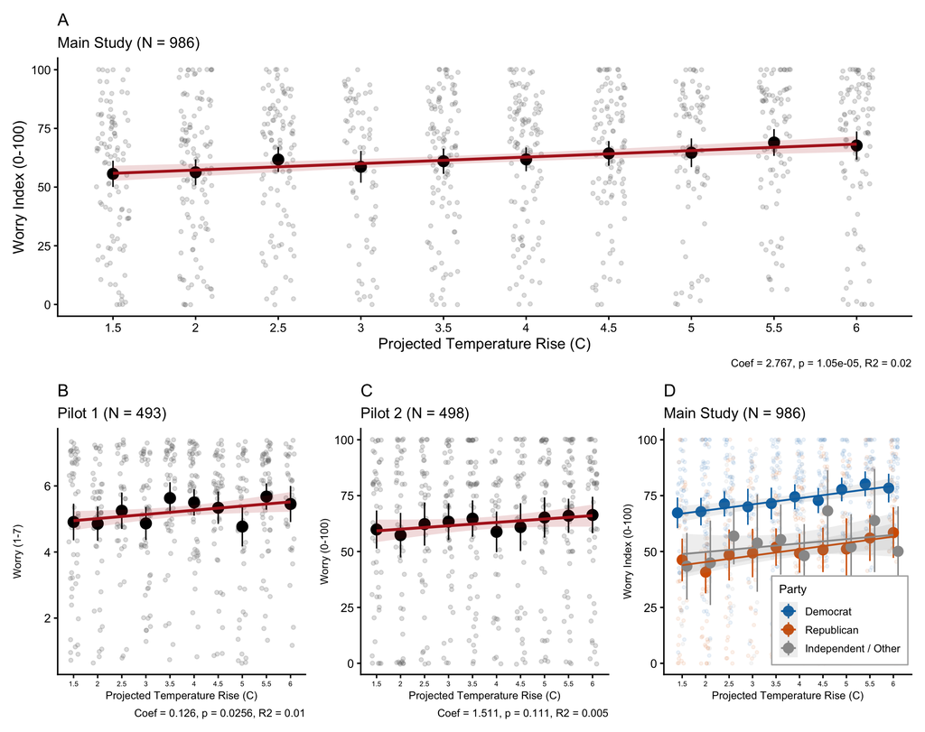

```r
m_index <- lm(worry_index ~ temp_numeric_c, data = v1)
m_p1 <- lm(worry ~ temp_numeric, data = p1)
m_p2 <- lm(worry ~ temp_numeric, data = p2)

model_caption <- function(model, digits = 3) {
  slope <- coef(model)[2]
  p_value <- summary(model)$coefficients[2, 4]
  r2 <- summary(model)$r.squared
  paste0(
    "Coef = ", format(round(slope, digits), nsmall = digits),
    ", p = ", format.pval(p_value, digits = 3),
    ", R2 = ", format(round(r2, 3), nsmall = ifelse(r2 < 0.01, 3, 2))
  )
}

set.seed(123)
temp_breaks <- seq(1.5, 6, by = 0.5)
temp_labels <- as.character(temp_breaks)

paper_theme <- theme_classic(base_size = 14) +
  theme(
    plot.title = element_text(face = "plain", size = 16),
    plot.subtitle = element_text(face = "plain", size = 14),
    plot.caption = element_text(size = 10, hjust = 1),
    axis.title = element_text(face = "plain")
  )

plot_a <- ggplot(v1, aes(x = temp_numeric_c, y = worry_index)) +
  geom_jitter(width = 0.1, alpha = 0.22, color = "gray45", size = 1.4) +
  stat_summary(aes(group = 1), fun.data = mean_cl_normal,
               geom = "pointrange", size = 0.9, color = "black") +
  geom_smooth(method = "lm", se = TRUE, aes(group = 1),
              color = "firebrick", fill = "firebrick", alpha = 0.16) +
  scale_x_continuous(breaks = temp_breaks, labels = temp_labels) +
  coord_cartesian(ylim = c(0, 100)) +
  paper_theme +
  labs(
    title = "A", subtitle = paste0("Main Study (N = ", nrow(v1), ")"),
    x = "Projected Temperature Rise (C)", y = "Worry Index (0-100)",
    caption = model_caption(m_index)
  )

plot_b <- ggplot(p1, aes(x = temp_numeric, y = worry)) +
  geom_jitter(width = 0.1, alpha = 0.22, color = "gray45", size = 1.4) +
  stat_summary(aes(group = 1), fun.data = mean_cl_normal,
               geom = "pointrange", size = 0.9, color = "black") +
  geom_smooth(method = "lm", se = TRUE, aes(group = 1),
              color = "firebrick", fill = "firebrick", alpha = 0.16) +
  scale_x_continuous(breaks = temp_breaks, labels = temp_labels) +
  paper_theme +
  theme(axis.text.x = element_text(size = 6.5), axis.title = element_text(size = 10)) +
  labs(
    title = "B", subtitle = paste0("Pilot 1 (N = ", nrow(p1), ")"),
    x = "Projected Temperature Rise (C)", y = "Worry (1-7)",
    caption = model_caption(m_p1)
  )

plot_c <- ggplot(p2, aes(x = temp_numeric, y = worry)) +
  geom_jitter(width = 0.1, alpha = 0.22, color = "gray45", size = 1.4) +
  stat_summary(aes(group = 1), fun.data = mean_cl_normal,
               geom = "pointrange", size = 0.9, color = "black") +
  geom_smooth(method = "lm", se = TRUE, aes(group = 1),
              color = "firebrick", fill = "firebrick", alpha = 0.16) +
  scale_x_continuous(breaks = temp_breaks, labels = temp_labels) +
  coord_cartesian(ylim = c(0, 100)) +
  paper_theme +
  theme(axis.text.x = element_text(size = 6.5), axis.title = element_text(size = 10)) +
  labs(
    title = "C", subtitle = paste0("Pilot 2 (N = ", nrow(p2), ")"),
    x = "Projected Temperature Rise (C)", y = "Worry (0-100)",
    caption = model_caption(m_p2)
  )

# Figure 1D retains non-leaning Independents/Other as a third descriptive group
# (N=986), matching the main-paper figure.
party_three <- v1 |>
  mutate(
    party_figure = case_when(
      partyid == "Democrat" | leaning == "Closer to Democratic" ~ "Democrat",
      partyid == "Republican" | leaning == "Closer to Republican" ~ "Republican",
      TRUE ~ "Independent / Other"
    ),
    party_figure = factor(
      party_figure,
      levels = c("Democrat", "Republican", "Independent / Other")
    )
  )

# Tables 11 and 5 use two-party coding, including leaners (N=845).
party_binary_df <- v1 |>
  mutate(
    party_binary = case_when(
      partyid == "Democrat" ~ "Democrat",
      partyid == "Republican" ~ "Republican",
      partyid %in% c("Independent", "No preference", "Other party") &
        leaning == "Closer to Democratic" ~ "Democrat",
      partyid %in% c("Independent", "No preference", "Other party") &
        leaning == "Closer to Republican" ~ "Republican",
      TRUE ~ NA_character_
    ),
    party_binary = factor(party_binary, levels = c("Democrat", "Republican"))
  ) |>
  tidyr::drop_na(party_binary)

plot_d <- ggplot(
  party_three,
  aes(x = temp_numeric_c, y = worry_index, color = party_figure, group = party_figure)
) +
  geom_jitter(width = 0.1, alpha = 0.08, size = 1.1) +
  stat_summary(fun.data = mean_cl_normal,
               geom = "pointrange", size = 0.8, position = position_dodge(width = 0.3)) +
  geom_smooth(method = "lm", se = TRUE, alpha = 0.15, linewidth = 0.8) +
  scale_x_continuous(breaks = temp_breaks, labels = temp_labels) +
  scale_color_manual(
    values = c(
      "Democrat" = "#0072B2",
      "Republican" = "#D55E00",
      "Independent / Other" = "#999999"
    )
  ) +
  paper_theme +
  theme(legend.position = "inside", legend.position.inside = c(0.71, 0.22),
        legend.background = element_rect(fill = "white", color = "gray70"),
        legend.text = element_text(size = 10), legend.title = element_text(size = 11)) +
  theme(axis.text.x = element_text(size = 6.5), axis.title = element_text(size = 10)) +
  coord_cartesian(ylim = c(0, 100)) +
  labs(
    title = "D", subtitle = paste0("Main Study (N = ", nrow(party_three), ")"),
    x = "Projected Temperature Rise (C)", y = "Worry Index (0-100)", color = "Party"
  )

fig1 <- plot_a / (plot_b | plot_c | plot_d) +
  plot_layout(heights = c(1.05, 1))
fig1
```

```r
dir.create(file.path("outputs", "figures"), recursive = TRUE, showWarnings = FALSE)
ggsave(file.path("outputs", "figures", "Figure1.pdf"), fig1, width = 12, height = 9.5)
```

## 3 3) Study Chronology and Participant Flow

The public data exclude collection timestamps and direct participant identifiers. The dates and exclusion counts below reproduce the participant-flow table in the final SI.

```r
s1_flow <- tibble::tribble(
  ~Study, ~`Collection dates`, ~`Initial N`, ~`Did not consent`, ~`Failed attention check`, ~`Speeding exclusion`, ~`Final N`,
  "Pilot 1", "Sep. 22-23, 2025", 500, 1, 6, 0, 493,
  "Pilot 2", "Sep. 25-26, 2025", 504, 0, 6, 0, 498,
  "Main study", "Oct. 11-13, 2025", 1005, 1, 6, 12, 986
)

kable(s1_flow, caption = "Participant flow")
```

Participant flow

| Study | Collection dates | Initial N | Did not consent | Failed attention check | Speeding exclusion | Final N |
| --- | --- | --- | --- | --- | --- | --- |
| Pilot 1 | Sep. 22-23, 2025 | 500 | 1 | 6 | 0 | 493 |
| Pilot 2 | Sep. 25-26, 2025 | 504 | 0 | 6 | 0 | 498 |
| Main study | Oct. 11-13, 2025 | 1005 | 1 | 6 | 12 | 986 |

## 4 4) Main OLS

```r
s1_model <- lm(worry_index ~ temp_numeric_c, data = v1)
s1_tidy <- tidy(s1_model, conf.int = TRUE) |>
  transmute(
    Predictor = dplyr::recode(term,
                              `(Intercept)` = "(Intercept)",
                              temp_numeric_c = "Projected warming (C)"),
    Coefficient = round(estimate, 3),
    `Std. Error` = round(std.error, 3),
    `95% CI` = paste0("[", round(conf.low, 2), ", ", round(conf.high, 2), "]"),
    `p-value` = signif(p.value, 3)
  )

s1_fit <- glance(s1_model)

kable(s1_tidy, caption = "Table 1. Linear regression model predicting worry index")
```

Table 1. Linear regression model predicting worry index

| Predictor | Coefficient | Std. Error | 95% CI | p-value |
| --- | --- | --- | --- | --- |
| (Intercept) | 51.718 | 2.478 | [46.86, 56.58] | 0.00e+00 |
| Projected warming (C) | 2.767 | 0.625 | [1.54, 3.99] | 1.05e-05 |

```r
kable(
  tibble::tibble(
    N = nrow(v1),
    `R-squared` = round(s1_fit$r.squared, 3),
    `Adjusted R-squared` = round(s1_fit$adj.r.squared, 3)
  ),
  caption = "Table 1 model fit"
)
```

Table 1 model fit

| N | R-squared | Adjusted R-squared |
| --- | --- | --- |
| 986 | 0.02 | 0.019 |

## 5 5) Holm-Corrected Pairwise Comparisons

```r
cohen_d_pairs <- pairwise_cohens_d(v1, "worry_index", "temp_condition")

s2_pairs <- cohen_d_pairs |>
  mutate(p.adj = p.adjust(p, method = "holm")) |>
  transmute(
    Group1 = group1, Group2 = group2, N1 = n1, N2 = n2,
    t = statistic, df = df, p = p, p_adj = p.adj,
    `Cohen's d` = cohen_d
  )

kable(s2_pairs |> select(-`Cohen's d`), digits = 4, caption = "Table 2. Pairwise contrasts across warming conditions with Holm correction")
```

Table 2. Pairwise contrasts across warming conditions with Holm correction

| Group1 | Group2 | N1 | N2 | t | df | p | p_adj |
| --- | --- | --- | --- | --- | --- | --- | --- |
| 1.5 | 2 | 101 | 113 | -0.1643 | 210.7023 | 0.8696 | 1.0000 |
| 1.5 | 2.5 | 101 | 102 | -1.5633 | 200.2496 | 0.1196 | 1.0000 |
| 1.5 | 3 | 101 | 73 | -0.6723 | 153.3969 | 0.5024 | 1.0000 |
| 1.5 | 3.5 | 101 | 109 | -1.3659 | 206.7954 | 0.1735 | 1.0000 |
| 1.5 | 4 | 101 | 115 | -1.6152 | 208.3519 | 0.1078 | 1.0000 |
| 1.5 | 4.5 | 101 | 102 | -2.2450 | 200.0718 | 0.0259 | 1.0000 |
| 1.5 | 5 | 101 | 86 | -2.1474 | 180.0185 | 0.0331 | 1.0000 |
| 1.5 | 5.5 | 101 | 89 | -3.3078 | 186.7379 | 0.0011 | 0.0508 |
| 1.5 | 6 | 101 | 96 | -2.9112 | 193.2765 | 0.0040 | 0.1730 |
| 2 | 2.5 | 113 | 102 | -1.4122 | 212.9375 | 0.1594 | 1.0000 |
| 2 | 3 | 113 | 73 | -0.5298 | 155.3519 | 0.5970 | 1.0000 |
| 2 | 3.5 | 113 | 109 | -1.2138 | 219.9990 | 0.2261 | 1.0000 |
| 2 | 4 | 113 | 115 | -1.4620 | 224.3353 | 0.1451 | 1.0000 |
| 2 | 4.5 | 113 | 102 | -2.1013 | 212.9778 | 0.0368 | 1.0000 |
| 2 | 5 | 113 | 86 | -2.0115 | 185.7889 | 0.0457 | 1.0000 |
| 2 | 5.5 | 113 | 89 | -3.1801 | 194.9398 | 0.0017 | 0.0754 |
| 2 | 6 | 113 | 96 | -2.7820 | 200.9790 | 0.0059 | 0.2485 |
| 2.5 | 3 | 102 | 73 | 0.7203 | 148.3048 | 0.4725 | 1.0000 |
| 2.5 | 3.5 | 102 | 109 | 0.1890 | 208.9528 | 0.8503 | 1.0000 |
| 2.5 | 4 | 102 | 115 | -0.0213 | 212.7201 | 0.9830 | 1.0000 |
| 2.5 | 4.5 | 102 | 102 | -0.6966 | 201.9903 | 0.4868 | 1.0000 |
| 2.5 | 5 | 102 | 86 | -0.7096 | 176.8736 | 0.4789 | 1.0000 |
| 2.5 | 5.5 | 102 | 89 | -1.8496 | 185.1866 | 0.0660 | 1.0000 |
| 2.5 | 6 | 102 | 96 | -1.4804 | 191.3900 | 0.1404 | 1.0000 |
| 3 | 3.5 | 73 | 109 | -0.5495 | 152.3814 | 0.5835 | 1.0000 |
| 3 | 4 | 73 | 115 | -0.7505 | 147.1473 | 0.4542 | 1.0000 |
| 3 | 4.5 | 73 | 102 | -1.3312 | 147.6148 | 0.1852 | 1.0000 |
| 3 | 5 | 73 | 86 | -1.3104 | 152.0193 | 0.1920 | 1.0000 |
| 3 | 5.5 | 73 | 89 | -2.3315 | 149.5415 | 0.0211 | 0.8635 |
| 3 | 6 | 73 | 96 | -1.9985 | 156.9086 | 0.0474 | 1.0000 |
| 3.5 | 4 | 109 | 115 | -0.2141 | 220.2803 | 0.8307 | 1.0000 |
| 3.5 | 4.5 | 109 | 102 | -0.8798 | 208.9863 | 0.3800 | 1.0000 |
| 3.5 | 5 | 109 | 86 | -0.8794 | 182.2359 | 0.3803 | 1.0000 |
| 3.5 | 5.5 | 109 | 89 | -2.0156 | 191.1759 | 0.0452 | 1.0000 |
| 3.5 | 6 | 109 | 96 | -1.6454 | 197.2539 | 0.1015 | 1.0000 |
| 4 | 4.5 | 115 | 102 | -0.6901 | 213.0122 | 0.4909 | 1.0000 |
| 4 | 5 | 115 | 86 | -0.7028 | 179.3145 | 0.4831 | 1.0000 |
| 4 | 5.5 | 115 | 89 | -1.8653 | 190.3271 | 0.0637 | 1.0000 |
| 4 | 6 | 115 | 96 | -1.4879 | 195.9109 | 0.1384 | 1.0000 |
| 4.5 | 5 | 102 | 86 | -0.0661 | 176.3472 | 0.9474 | 1.0000 |
| 4.5 | 5.5 | 102 | 89 | -1.1854 | 184.8194 | 0.2374 | 1.0000 |
| 4.5 | 6 | 102 | 96 | -0.8334 | 190.9868 | 0.4057 | 1.0000 |
| 5 | 5.5 | 86 | 89 | -1.0376 | 171.7890 | 0.3009 | 1.0000 |
| 5 | 6 | 86 | 96 | -0.7150 | 179.0788 | 0.4756 | 1.0000 |
| 5.5 | 6 | 89 | 96 | 0.3077 | 182.9720 | 0.7587 | 1.0000 |

## 6 6) Unit Framing Interaction

```r
s3_model <- lm(worry_index ~ temp_centered_c * unit_condition, data = v1)
s3_tidy <- tidy(s3_model, conf.int = TRUE) |>
  transmute(
    Predictor = dplyr::recode(term,
                              `(Intercept)` = "(Intercept)",
                              temp_centered_c = "Projected warming (centered at 3.699 C)",
                              unit_conditionF = "Unit condition [Fahrenheit]",
                              `temp_centered_c:unit_conditionF` = "Warming x Unit [Fahrenheit]"),
    Coefficient = round(estimate, 3),
    `Std. Error` = round(std.error, 3),
    `95% CI` = paste0("[", round(conf.low, 2), ", ", round(conf.high, 2), "]"),
    `p-value` = signif(p.value, 3)
  )

s3_fit <- glance(s3_model)

kable(s3_tidy, caption = "Table 3. Interaction model: warming x unit framing")
```

Table 3. Interaction model: warming x unit framing

| Predictor | Coefficient | Std. Error | 95% CI | p-value |
| --- | --- | --- | --- | --- |
| (Intercept) | 59.734 | 1.283 | [57.22, 62.25] | 0.000000 |
| Projected warming (centered at 3.699 C) | 3.162 | 0.884 | [1.43, 4.9] | 0.000362 |
| Unit condition [Fahrenheit] | 4.274 | 1.786 | [0.77, 7.78] | 0.016900 |
| Warming x Unit [Fahrenheit] | -0.712 | 1.247 | [-3.16, 1.74] | 0.568000 |

```r
kable(
  tibble::tibble(
    N = nrow(v1),
    `R-squared` = round(s3_fit$r.squared, 3),
    `Adjusted R-squared` = round(s3_fit$adj.r.squared, 3)
  ),
  caption = "Table 3 model fit"
)
```

Table 3 model fit

| N | R-squared | Adjusted R-squared |
| --- | --- | --- |
| 986 | 0.026 | 0.023 |

## 7 7) Text Embedding Results

Run this from the repository root if needed:

```bash
python3 text_embedding/run_text_embedding.py
```

```r
path_s4 <- file.path("outputs", "tables", "table_s12.csv")
if (file.exists(path_s4)) {
  s4 <- read_csv(path_s4, show_col_types = FALSE)
  kable(s4, caption = "Table 4. Embedding model results")
} else {
  cat("Embedding results file not found. Run: python3 text_embedding/run_text_embedding.py\n")
}
```

Table 4. Embedding model results

| Model | Version | Delta_Obs | P_Value | Within_Mean | Between_Mean | Significance |
| --- | --- | --- | --- | --- | --- | --- |
| BGE-Large | CLEAN | 0.0009501 | 0.0759241 | 0.6204659 | 0.6195158 | Marginal |
| BGE-Large | RAW | 0.0011089 | 0.0409590 | 0.6186336 | 0.6175247 | Sig. |
| E5-Large | CLEAN | 0.0000406 | 0.8601399 | 0.8317859 | 0.8317453 | Non-sig. |
| E5-Large | RAW | 0.0001391 | 0.5804196 | 0.8303973 | 0.8302582 | Non-sig. |
| MPNet-Base | CLEAN | 0.0023316 | 0.0179820 | 0.4647068 | 0.4623751 | Sig. |
| MPNet-Base | RAW | 0.0022335 | 0.0249750 | 0.4644511 | 0.4622175 | Sig. |
| MiniLM-L6 | CLEAN | 0.0013126 | 0.1228771 | 0.4050819 | 0.4037693 | Non-sig. |
| MiniLM-L6 | RAW | 0.0013261 | 0.1098901 | 0.3997841 | 0.3984581 | Non-sig. |
| Mxbai-Large | CLEAN | 0.0008066 | 0.1588412 | 0.6168437 | 0.6160371 | Non-sig. |
| Mxbai-Large | RAW | 0.0009479 | 0.1018981 | 0.6144717 | 0.6135238 | Non-sig. |

## 8 8) Party x Temperature Model

The interaction term for projected warming by party is not statistically significant (`p = 0.938` for Republican vs Democrat slope difference), indicating little evidence that warming sensitivity differs by party.

```r
s5_interaction_model <- lm(worry_index ~ temp_numeric_c * party_binary, data = party_binary_df)

s5_interaction <- tidy(s5_interaction_model, conf.int = TRUE) |>
  transmute(
    Term = term,
    Coefficient = round(estimate, 3),
    `Std. Error` = round(std.error, 3),
    `95% CI` = paste0("[", round(conf.low, 2), ", ", round(conf.high, 2), "]"),
    `p-value` = signif(p.value, 3)
  )

s5_fit <- glance(s5_interaction_model)

kable(s5_interaction, caption = "Table 5. Interaction model for party-specific sensitivity to projected warming")
```

Table 5. Interaction model for party-specific sensitivity to projected warming

| Term | Coefficient | Std. Error | 95% CI | p-value |
| --- | --- | --- | --- | --- |
| (Intercept) | 62.864 | 3.140 | [56.7, 69.03] | 0.000000 |
| temp_numeric_c | 2.746 | 0.787 | [1.2, 4.29] | 0.000511 |
| party_binaryRepublican | -23.235 | 4.851 | [-32.76, -13.71] | 0.000002 |
| temp_numeric_c:party_binaryRepublican | 0.095 | 1.222 | [-2.3, 2.49] | 0.938000 |

```r
kable(
  tibble::tibble(
    N = nrow(party_binary_df),
    `R-squared` = round(s5_fit$r.squared, 3),
    `Adjusted R-squared` = round(s5_fit$adj.r.squared, 3)
  ),
  caption = "Table 5 model fit"
)
```

Table 5 model fit

| N | R-squared | Adjusted R-squared |
| --- | --- | --- |
| 845 | 0.186 | 0.183 |

## 9 9) Pilot 1 Full Regression Results

Pilot analyses use the same linear trend specification as the main model, regressing each pilot outcome on projected warming magnitude (in C).

```r
s6_p1 <- tidy(m_p1, conf.int = TRUE) |>
  transmute(
    Predictor = dplyr::recode(term, `(Intercept)` = "(Intercept)", temp_numeric = "Projected warming (C)"),
    Coefficient = round(estimate, 3),
    `Std. Error` = round(std.error, 3),
    `t-stat` = round(statistic, 3),
    `95% CI` = paste0("[", round(conf.low, 2), ", ", round(conf.high, 2), "]"),
    `p-value` = signif(p.value, 3)
  )

s6_fit <- glance(m_p1)

kable(s6_p1, caption = "Table 6. Pilot 1 full OLS regression (Outcome: Worry 1-7)")
```

Table 6. Pilot 1 full OLS regression (Outcome: Worry 1-7)

| Predictor | Coefficient | Std. Error | t-stat | 95% CI | p-value |
| --- | --- | --- | --- | --- | --- |
| (Intercept) | 4.759 | 0.224 | 21.286 | [4.32, 5.2] | 0.0000 |
| Projected warming (C) | 0.126 | 0.056 | 2.239 | [0.02, 0.24] | 0.0256 |

```r
kable(
  tibble::tibble(
    N = nrow(p1),
    `R-squared` = round(s6_fit$r.squared, 3),
    `Adjusted R-squared` = round(s6_fit$adj.r.squared, 3),
    Sigma = round(s6_fit$sigma, 3)
  ),
  caption = "Table 6 model fit"
)
```

Table 6 model fit

| N | R-squared | Adjusted R-squared | Sigma |
| --- | --- | --- | --- |
| 493 | 0.01 | 0.008 | 1.762 |

## 10 10) Pilot 2 Full Regression Results

```r
s7_p2 <- tidy(m_p2, conf.int = TRUE) |>
  transmute(
    Predictor = dplyr::recode(term, `(Intercept)` = "(Intercept)", temp_numeric = "Projected warming (C)"),
    Coefficient = round(estimate, 3),
    `Std. Error` = round(std.error, 3),
    `t-stat` = round(statistic, 3),
    `95% CI` = paste0("[", round(conf.low, 2), ", ", round(conf.high, 2), "]"),
    `p-value` = signif(p.value, 3)
  )

s7_fit <- glance(m_p2)

kable(s7_p2, caption = "Table 7. Pilot 2 full OLS regression (Outcome: Worry 0-100)")
```

Table 7. Pilot 2 full OLS regression (Outcome: Worry 0-100)

| Predictor | Coefficient | Std. Error | t-stat | 95% CI | p-value |
| --- | --- | --- | --- | --- | --- |
| (Intercept) | 56.985 | 3.838 | 14.849 | [49.44, 64.52] | 0.000 |
| Projected warming (C) | 1.511 | 0.946 | 1.598 | [-0.35, 3.37] | 0.111 |

```r
kable(
  tibble::tibble(
    N = nrow(p2),
    `R-squared` = round(s7_fit$r.squared, 3),
    `Adjusted R-squared` = round(s7_fit$adj.r.squared, 3),
    Sigma = round(s7_fit$sigma, 3)
  ),
  caption = "Table 7 model fit"
)
```

Table 7 model fit

| N | R-squared | Adjusted R-squared | Sigma |
| --- | --- | --- | --- |
| 498 | 0.005 | 0.003 | 30.929 |

## 11 11) Item-Level Regressions

Each main-study item is regressed separately on assigned warming. Pilot regressions report the single worry item collected in each pilot.

```r
s8_fit <- lm(QID5_1 ~ temp_numeric_c, data = v1)
s9_fit <- lm(Q17_1 ~ temp_numeric_c, data = v1)
s10_fit <- lm(Q18_1 ~ temp_numeric_c, data = v1)
for (entry in list(list(s8_fit, "8. Worry assigned temperature"),
                   list(s9_fit, "9. Harm to US people"),
                   list(s10_fit, "10. Personal harm"))) {
  print(kable(tidy(entry[[1]], conf.int = TRUE), digits = 3,
              caption = paste("Table", entry[[2]])))
  print(kable(glance(entry[[1]]) |> select(nobs, r.squared, adj.r.squared),
              digits = 3, caption = paste("Model fit:", entry[[2]])))
}
```

Table 8. Worry assigned temperature

| term | estimate | std.error | statistic | p.value | conf.low | conf.high |
| --- | --- | --- | --- | --- | --- | --- |
| (Intercept) | 56.651 | 2.626 | 21.570 | 0 | 51.497 | 61.805 |
| temp_numeric_c | 2.591 | 0.662 | 3.913 | 0 | 1.291 | 3.890 |

Model fit: 8. Worry assigned temperature

| nobs | r.squared | adj.r.squared |
| --- | --- | --- |
| 986 | 0.015 | 0.014 |

Table 9. Harm to US people

| term | estimate | std.error | statistic | p.value | conf.low | conf.high |
| --- | --- | --- | --- | --- | --- | --- |
| (Intercept) | 57.237 | 2.504 | 22.859 | 0 | 52.323 | 62.150 |
| temp_numeric_c | 2.519 | 0.631 | 3.990 | 0 | 1.280 | 3.758 |

Model fit: 9. Harm to US people

| nobs | r.squared | adj.r.squared |
| --- | --- | --- |
| 986 | 0.016 | 0.015 |

Table 10. Personal harm

| term | estimate | std.error | statistic | p.value | conf.low | conf.high |
| --- | --- | --- | --- | --- | --- | --- |
| (Intercept) | 41.266 | 2.881 | 14.325 | 0 | 35.613 | 46.919 |
| temp_numeric_c | 3.191 | 0.726 | 4.394 | 0 | 1.766 | 4.617 |

Model fit: 10. Personal harm

| nobs | r.squared | adj.r.squared |
| --- | --- | --- |
| 986 | 0.019 | 0.018 |

## 12 12) Within-Party Regressions

```r
s11_models <- party_binary_df |>
  group_by(party_binary) |>
  group_map(~ lm(worry_index ~ temp_numeric_c, data = .x), .keep = TRUE)
names(s11_models) <- levels(party_binary_df$party_binary)

s11 <- bind_rows(lapply(names(s11_models), function(group_name) {
  model <- s11_models[[group_name]]
  slope <- tidy(model, conf.int = TRUE) |> filter(term == "temp_numeric_c")
  intercept <- tidy(model, conf.int = TRUE) |> filter(term == "(Intercept)")
  fit <- glance(model)
  tibble(
    Party = group_name,
    N = nobs(model),
    Intercept = intercept$estimate,
    `Intercept SE` = intercept$std.error,
    `Intercept t` = intercept$statistic,
    `Intercept p` = intercept$p.value,
    `Intercept CI low` = intercept$conf.low,
    `Intercept CI high` = intercept$conf.high,
    `Projected warming` = slope$estimate,
    `Projected warming SE` = slope$std.error,
    `Projected warming t` = slope$statistic,
    `Projected warming CI low` = slope$conf.low,
    `Projected warming CI high` = slope$conf.high,
    `p-value` = slope$p.value,
    `R-squared` = fit$r.squared,
    `Adjusted R-squared` = fit$adj.r.squared
  )
}))

kable(
  s11 |> mutate(across(where(is.numeric), ~ round(.x, 3))),
  caption = "Table 11. Within-party linear regressions of worry index on projected warming"
)
```

Table 11. Within-party linear regressions of worry index on projected warming

| Party | N | Intercept | Intercept SE | Intercept t | Intercept p | Intercept CI low | Intercept CI high | Projected warming | Projected warming SE | Projected warming t | Projected warming CI low | Projected warming CI high | p-value | R-squared | Adjusted R-squared |
| --- | --- | --- | --- | --- | --- | --- | --- | --- | --- | --- | --- | --- | --- | --- | --- |
| Democrat | 491 | 62.864 | 2.687 | 23.396 | 0 | 57.584 | 68.143 | 2.746 | 0.674 | 4.077 | 1.423 | 4.070 | 0.00 | 0.033 | 0.031 |
| Republican | 354 | 39.629 | 4.330 | 9.151 | 0 | 31.112 | 48.146 | 2.841 | 1.094 | 2.596 | 0.688 | 4.993 | 0.01 | 0.019 | 0.016 |

## 13 13) Post Hoc LLM-Check Sensitivity

`outputs/tables/table_s13.csv` contains aggregate results after excluding 19 responses matched to Prolific’s post hoc LLM-check export. Reproducing this exclusion requires the nonpublic participant-level classification; see `sensitivity/README.md`.

```r
s13 <- read_csv(
  file.path("outputs", "tables", "table_s13.csv"),
  show_col_types = FALSE
)

kable(
  s13,
  digits = 6,
  caption = "Table 12. Sensitivity analyses excluding 19 accounts matched from Prolific's post hoc LLM-check export"
)
```

Table 12. Sensitivity analyses excluding 19 accounts matched from Prolific’s post hoc LLM-check export

| panel | model | input | full_N | full_estimate | full_SE | full_p | full_R_squared | exclusion_N | exclusion_estimate | exclusion_SE | exclusion_p | exclusion_R_squared |
| --- | --- | --- | --- | --- | --- | --- | --- | --- | --- | --- | --- | --- |
| A | Continuous-temperature OLS | NA | 986 | 2.766949 | 0.624658 | 0.000011 | 0.01955 | 967 | 2.862818 | 0.63297 | 0.000007 | 0.020758 |
| B | MPNet-Base | Raw | 986 | 0.002234 | NA | 0.024975 | NA | 967 | 0.001947 | NA | 0.051948 | NA |
| B | MPNet-Base | Clean | 986 | 0.002332 | NA | 0.017982 | NA | 967 | 0.002020 | NA | 0.052947 | NA |
| B | MiniLM-L6 | Raw | 986 | 0.001326 | NA | 0.109890 | NA | 967 | 0.001023 | NA | 0.246753 | NA |
| B | MiniLM-L6 | Clean | 986 | 0.001313 | NA | 0.122877 | NA | 967 | 0.001033 | NA | 0.261738 | NA |
| B | E5-Large | Raw | 986 | 0.000139 | NA | 0.580420 | NA | 967 | 0.000056 | NA | 0.826174 | NA |
| B | E5-Large | Clean | 986 | 0.000041 | NA | 0.860140 | NA | 967 | -0.000049 | NA | 0.860140 | NA |
| B | BGE-Large | Raw | 986 | 0.001109 | NA | 0.040959 | NA | 967 | 0.000920 | NA | 0.075924 | NA |
| B | BGE-Large | Clean | 986 | 0.000950 | NA | 0.075924 | NA | 967 | 0.000764 | NA | 0.145854 | NA |
| B | Mxbai-Large | Raw | 986 | 0.000948 | NA | 0.101898 | NA | 967 | 0.000728 | NA | 0.197802 | NA |
| B | Mxbai-Large | Clean | 986 | 0.000807 | NA | 0.158841 | NA | 967 | 0.000590 | NA | 0.312687 | NA |

## 14 14) Machine-Readable Output Tables

The CSV files below contain the analysis results. Their numbering is mapped to the statistical PDF tables in `extended_analysis/README.md`.

```r
dir.create(file.path("outputs", "tables"), recursive = TRUE, showWarnings = FALSE)

model_export <- function(model) {
  fit <- glance(model)
  tidy(model, conf.int = TRUE) |>
    mutate(
      N = nobs(model),
      R_squared = fit$r.squared,
      adjusted_R_squared = fit$adj.r.squared
    )
}

write_csv(s1_flow, file.path("outputs", "tables", "table_s1.csv"))
write_csv(model_export(s1_model), file.path("outputs", "tables", "table_s2.csv"))
write_csv(model_export(m_p1), file.path("outputs", "tables", "table_s3.csv"))
write_csv(model_export(m_p2), file.path("outputs", "tables", "table_s4.csv"))
write_csv(model_export(s8_fit), file.path("outputs", "tables", "table_s5.csv"))
write_csv(model_export(s9_fit), file.path("outputs", "tables", "table_s6.csv"))
write_csv(model_export(s10_fit), file.path("outputs", "tables", "table_s7.csv"))
write_csv(s2_pairs, file.path("outputs", "tables", "table_s8.csv"))
write_csv(s11, file.path("outputs", "tables", "table_s9.csv"))
write_csv(model_export(s5_interaction_model), file.path("outputs", "tables", "table_s10.csv"))
write_csv(model_export(s3_model) |> mutate(centering_value = mean(v1$temp_numeric_c)),
          file.path("outputs", "tables", "table_s11.csv"))
# table_s12.csv is generated by text_embedding/run_text_embedding.py;
# table_s13.csv contains archived aggregate sensitivity results.

kable(
  tibble(
    Output = c("Participant flow", "1", "6", "7", "8", "9", "10",
               "2", "11", "5", "3", "4", "12"),
    File = file.path("outputs", "tables", paste0("table_s", 1:13, ".csv"))
  ),
  caption = "Machine-readable SI table outputs"
)
```

Machine-readable SI table outputs

| Output | File |
| --- | --- |
| Participant flow | outputs/tables/table_s1.csv |
| 1 | outputs/tables/table_s2.csv |
| 6 | outputs/tables/table_s3.csv |
| 7 | outputs/tables/table_s4.csv |
| 8 | outputs/tables/table_s5.csv |
| 9 | outputs/tables/table_s6.csv |
| 10 | outputs/tables/table_s7.csv |
| 2 | outputs/tables/table_s8.csv |
| 11 | outputs/tables/table_s9.csv |
| 5 | outputs/tables/table_s10.csv |
| 3 | outputs/tables/table_s11.csv |
| 4 | outputs/tables/table_s12.csv |
| 12 | outputs/tables/table_s13.csv |